# ML01

Required csv file-> heart.csv

Download link: https://www.kaggle.com/datasets/zhaoyingzhu/heartcsv?resource=download

```python
import pandas as pd
import numpy as np
```

## pandas dataframe object

Dataframe == table. Contains an array of individual entries. Ex: pd.DataFrame({'Yes': [50, 21], 'No': [131, 2]})

## Reading csv file

```python
data = pd.read_csv('Heart.csv')
data
```

|  | Unnamed: 0 | Age | Sex | ChestPain | RestBP | Chol | Fbs | RestECG | MaxHR | ExAng | Oldpeak | Slope | Ca | Thal | AHD |
| --- | --- | --- | --- | --- | --- | --- | --- | --- | --- | --- | --- | --- | --- | --- | --- |
| 0 | 1 | 63 | 1 | typical | 145 | 233 | 1 | 2 | 150 | 0 | 2.3 | 3 | 0.0 | fixed | No |
| 1 | 2 | 67 | 1 | asymptomatic | 160 | 286 | 0 | 2 | 108 | 1 | 1.5 | 2 | 3.0 | normal | Yes |
| 2 | 3 | 67 | 1 | asymptomatic | 120 | 229 | 0 | 2 | 129 | 1 | 2.6 | 2 | 2.0 | reversable | Yes |
| 3 | 4 | 37 | 1 | nonanginal | 130 | 250 | 0 | 0 | 187 | 0 | 3.5 | 3 | 0.0 | normal | No |
| 4 | 5 | 41 | 0 | nontypical | 130 | 204 | 0 | 2 | 172 | 0 | 1.4 | 1 | 0.0 | normal | No |
| ... | ... | ... | ... | ... | ... | ... | ... | ... | ... | ... | ... | ... | ... | ... | ... |
| 298 | 299 | 45 | 1 | typical | 110 | 264 | 0 | 0 | 132 | 0 | 1.2 | 2 | 0.0 | reversable | Yes |
| 299 | 300 | 68 | 1 | asymptomatic | 144 | 193 | 1 | 0 | 141 | 0 | 3.4 | 2 | 2.0 | reversable | Yes |
| 300 | 301 | 57 | 1 | asymptomatic | 130 | 131 | 0 | 0 | 115 | 1 | 1.2 | 2 | 1.0 | reversable | Yes |
| 301 | 302 | 57 | 0 | nontypical | 130 | 236 | 0 | 2 | 174 | 0 | 0.0 | 2 | 1.0 | normal | Yes |
| 302 | 303 | 38 | 1 | nonanginal | 138 | 175 | 0 | 0 | 173 | 0 | 0.0 | 1 | NaN | normal | No |

303 rows × 15 columns

## check the shape of data

```python
data.shape #(rows, columns)
```

```
(303, 15)
```

## check for null values

The isna() method returns a DataFrame object where all the values are replaced with a Boolean value True for NA (not-a -number) values, and otherwise False.

```python
data.isna()
```

|  | Unnamed: 0 | Age | Sex | ChestPain | RestBP | Chol | Fbs | RestECG | MaxHR | ExAng | Oldpeak | Slope | Ca | Thal | AHD |
| --- | --- | --- | --- | --- | --- | --- | --- | --- | --- | --- | --- | --- | --- | --- | --- |
| 0 | False | False | False | False | False | False | False | False | False | False | False | False | False | False | False |
| 1 | False | False | False | False | False | False | False | False | False | False | False | False | False | False | False |
| 2 | False | False | False | False | False | False | False | False | False | False | False | False | False | False | False |
| 3 | False | False | False | False | False | False | False | False | False | False | False | False | False | False | False |
| 4 | False | False | False | False | False | False | False | False | False | False | False | False | False | False | False |
| ... | ... | ... | ... | ... | ... | ... | ... | ... | ... | ... | ... | ... | ... | ... | ... |
| 298 | False | False | False | False | False | False | False | False | False | False | False | False | False | False | False |
| 299 | False | False | False | False | False | False | False | False | False | False | False | False | False | False | False |
| 300 | False | False | False | False | False | False | False | False | False | False | False | False | False | False | False |
| 301 | False | False | False | False | False | False | False | False | False | False | False | False | False | False | False |
| 302 | False | False | False | False | False | False | False | False | False | False | False | False | True | False | False |

303 rows × 15 columns

### Check if there exists a null values in all columns of dataframe

isna(). sum() syntax returns the number of NaN values in all columns of a pandas DataFrame in Python

```python
data.isna().sum()
```

```
Unnamed: 0    0
Age           0
Sex           0
ChestPain     0
RestBP        0
Chol          0
Fbs           0
RestECG       0
MaxHR         0
ExAng         0
Oldpeak       0
Slope         0
Ca            4
Thal          2
AHD           0
dtype: int64
```

```python
#check total number of NaN values in the entire dataFrame
data.isna().sum().sum()
```

```
6
```

## Finding data type of each column

```python
# prints information about the dataframe.
# infor -> columns, columns labels, column data types, mem usage, etc
data.info()
```

```
<class 'pandas.core.frame.DataFrame'>
RangeIndex: 303 entries, 0 to 302
Data columns (total 15 columns):
 #   Column      Non-Null Count  Dtype
---  ------      --------------  -----
 0   Unnamed: 0  303 non-null    int64
 1   Age         303 non-null    int64
 2   Sex         303 non-null    int64
 3   ChestPain   303 non-null    object
 4   RestBP      303 non-null    int64
 5   Chol        303 non-null    int64
 6   Fbs         303 non-null    int64
 7   RestECG     303 non-null    int64
 8   MaxHR       303 non-null    int64
 9   ExAng       303 non-null    int64
 10  Oldpeak     303 non-null    float64
 11  Slope       303 non-null    int64
 12  Ca          299 non-null    float64
 13  Thal        301 non-null    object
 14  AHD         303 non-null    object
dtypes: float64(2), int64(10), object(3)
memory usage: 35.6+ KB
```

```python
# printing only data types of each columns
data.dtypes
```

```
Unnamed: 0      int64
Age             int64
Sex             int64
ChestPain      object
RestBP          int64
Chol            int64
Fbs             int64
RestECG         int64
MaxHR           int64
ExAng           int64
Oldpeak       float64
Slope           int64
Ca            float64
Thal           object
AHD            object
dtype: object
```

### Finding out zero's

axix=1 --> row (horizontal axis)

axis=0 --> column (vertical axis)

```python
(data==0).sum(axis=0)
```

```
Unnamed: 0      0
Age             0
Sex            97
ChestPain       0
RestBP          0
Chol            0
Fbs           258
RestECG       151
MaxHR           0
ExAng         204
Oldpeak        99
Slope           0
Ca            176
Thal            0
AHD             0
dtype: int64
```

```python
(data==0).sum(axis=1)
```

```
0      2
1      1
2      1
3      4
4      4
      ..
298    4
299    2
300    2
301    4
302    4
Length: 303, dtype: int64
```

### Finding out mean age of patients

```python
data["Age"].mean()
```

```
54.43894389438944
```

## Extracting only necessary columns

```python
df = data[["Age","Sex","ChestPain", "RestBP", "Chol"]]
df
```

|  | Age | Sex | ChestPain | RestBP | Chol |
| --- | --- | --- | --- | --- | --- |
| 0 | 63 | 1 | typical | 145 | 233 |
| 1 | 67 | 1 | asymptomatic | 160 | 286 |
| 2 | 67 | 1 | asymptomatic | 120 | 229 |
| 3 | 37 | 1 | nonanginal | 130 | 250 |
| 4 | 41 | 0 | nontypical | 130 | 204 |
| ... | ... | ... | ... | ... | ... |
| 298 | 45 | 1 | typical | 110 | 264 |
| 299 | 68 | 1 | asymptomatic | 144 | 193 |
| 300 | 57 | 1 | asymptomatic | 130 | 131 |
| 301 | 57 | 0 | nontypical | 130 | 236 |
| 302 | 38 | 1 | nonanginal | 138 | 175 |

303 rows × 5 columns

# Dividing data into train and test data set

25% data for testing 75% dat for training so that our model get data appropriately

```python
from sklearn.model_selection import train_test_split
x_train, x_test, y_train, y_test = train_test_split(df,data, test_size=0.25)
```

# Data Visualization

```python
import matplotlib.pyplot as plt
```

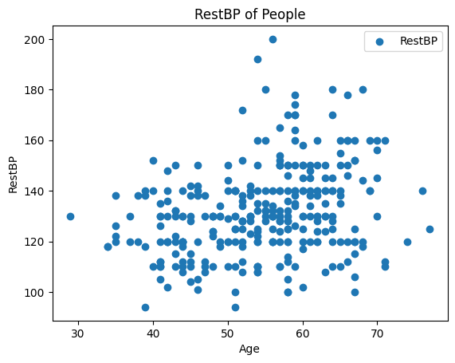

```python
plt.scatter(data.Age, data.RestBP, label="RestBP")
plt.xlabel("Age")
plt.ylabel("RestBP")
plt.title("RestBP of People")
plt.legend()
plt.show()
```

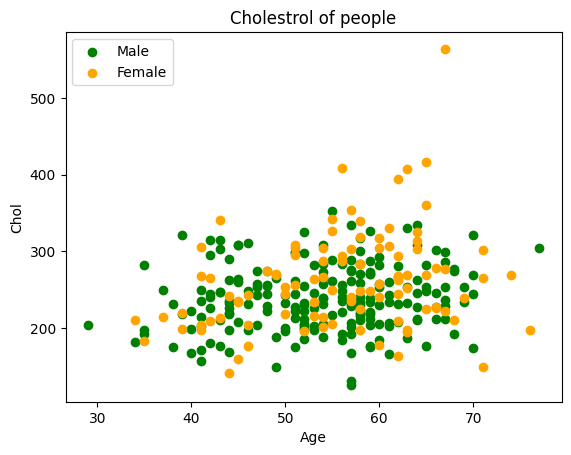

```python
plt.scatter(data.Age[data.Sex == 1], data.Chol[data.Sex ==1],color='green', label="Male")
plt.scatter(data.Age[data.Sex == 0], data.Chol[data.Sex ==0], color='orange', label="Female")
plt.xlabel("Age")
plt.ylabel("Chol")
plt.title("Cholestrol of people")
plt.legend(loc="upper left") ;
plt.show() ;
```

```python
temp = df.ChestPain
temp
```

```
0           typical
1      asymptomatic
2      asymptomatic
3        nonanginal
4        nontypical
           ...
298         typical
299    asymptomatic
300    asymptomatic
301      nontypical
302      nonanginal
Name: ChestPain, Length: 303, dtype: object
```

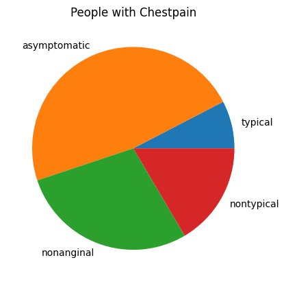

```python
data1 = [
    df.ChestPain[df.ChestPain == 'typical'].count(),
    df.ChestPain[df.ChestPain == 'asymptomatic'].count(),
    df.ChestPain[df.ChestPain == 'nonanginal'].count(),
    df.ChestPain[df.ChestPain == 'nontypical'].count()
]

label1 = ['typical', 'asymptomatic', 'nonanginal', 'nontypical']

plt.pie(data1, labels=label1)
plt.title("People with Chestpain")
plt.show()
```

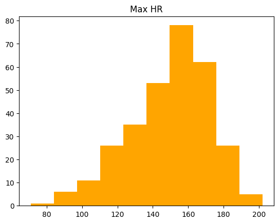

```python
plt.hist(data.MaxHR,bins=10, color='orange')
plt.title("Max HR")
plt.show()
```

```python
l = np.array([[9,5,6], [2,1,7]])
x=l.min(axis=0)
x
```

```
array([2, 1, 6])
```

# Assignment 1b Confusion matrix

Through the diagnosis test I predicted 100 report as COVID positive, but only 45 of those were actually positive. Total 50 people in my sample were actually COVID positive. I have total 500 samples. Create confusion matrix based on above data and find

1. Accuracy
2. Precision
3. Recall
4. F-1 score

### Generating Confusion matrix

```python
tp = 45
tn = 395
fp = 55
fn = 5
conf_mat = np.matrix([[tp, fp],[fn, tn]])
print(conf_mat)
```

```
[[ 45  55]
 [  5 395]]
```

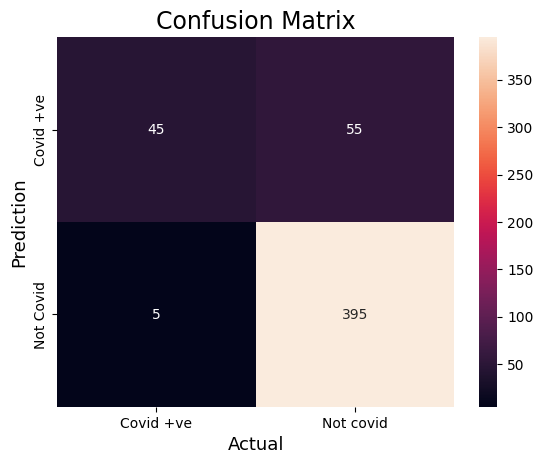

```python
from sklearn.metrics import confusion_matrix
import seaborn as sns
import matplotlib.pyplot as plt

# cm = confusion_matrix(conf_mat)
sns.heatmap(conf_mat,
            annot=True,
            fmt='g',
            xticklabels=['Covid +ve','Not covid'],
            yticklabels=['Covid +ve','Not Covid'])
plt.ylabel('Prediction',fontsize=13)
plt.xlabel('Actual',fontsize=13)
plt.title('Confusion Matrix',fontsize=17)
plt.show()
```

## Accuracy

Accuracy measures how often the model is correct

(TP + TN) / Total Predictions

```python
#using calculation
accuracy = (tp+tn) / (tp+tn+fn+fp)
accuracy
```

```
0.88
```

## Precision

Of the positives predicted, what percentage is truly positive?

How to Calculate:

TP / (TP + FP)

```python
precision = tp/(tp+fp)
precision
```

```
0.45
```

## Recall

Of all the positive cases, what percentage are predicted positive?

Sensitivity (sometimes called Recall) measures how good the model is at predicting positives.

This means it looks at true positives and false negatives (which are positives that have been incorrectly predicted as negative).

How to Calculate TP / (TP + FN)

```python
recall = tp/(tp+fn)
recall
```

```
0.9
```

## F-1 score

F1 score is the harmonic mean of precision and recall and is a better measure than accuracy.

2 *( (precision*recall) / (precision+recall) )

```python
f1_score = 2 * ((precision*recall)/ (precision+recall))
f1_score
```

```
0.6
```